# Modeling proportions

Summary: 0. In all SES variables including race, education, federal poverty level, home ownership, occupation, income, networth, and division, all NA values are coded as the same as the missing level (“0” or “U”).

1. Federal poverty level only has 3 levels “Above 400% FPL”, “Below 400% FPL”, and “Unkown”, and very few people (<=3) have “Below 400% FPL”. Thus fed_poverty is not used.
2. Home ownership only has “probable homeowner” and “unknown”. This does not provide useful information so is not used.
3. Occupation has >75% “unknown” and is thus not used.
4. For race, “Asian” and “Hispanic” are combined.
5. In index VTE types, the 3 smallest levels IVC, PV, RV, are combined.
6. In comorbidity, 2 additional covariates are created. comorb_01 = I{have at least one comorbidity}, and n_comorb = #{comorbidities}.
7. In education, “Less than 12th Grade” (“A”) and “High School Diploma” (“B”) is merged into “AB”.
8. In antiplatelets, antiplatelet = I{ have at least one antiplatelet}.

Covariates within consideration: age (scaled), male, index_vte_type (combined), comorbidities (individuals, comorb_01, or n_comorb), education (raw, or combined), income_range, networth_range, race (raw, or combined), division (raw, or combined), product, surgery, smoke, hospitalized, vte_history, antiplatelet

What to do with index cancer type, and lab tests? Index cancer type has many levels, and lab tests have small counts.

- To compare proportions of LMWH at index AC and AC3Mo,
1. Models have large intercept (~-8)
2. Without the two smallest education levels, MCMCglmm gives decent estimates. But how to validate the result and how to choose an appropriate prior?
- To compare proportions of Warfarin at index AC and AC3Mo,
1. Whenever education is included in the model, the model will not converge, no matter whether the two education levels with the smallest counts are removed.
2. Model does not converge in Rstudio but converges in command line. Model 3: warfarin ~ VTE_Lower.extremity.DVT + VTE_Other + VTE_Pulmonary.embolism + VTE_Upper.extremity.DVT + n_comorb + time + race + male + age_s + product + income_range + occupation + (1 | patid)

```r
dat <- data.table(readRDS("../../data/prog100_analysis_data.rds"))
# UNKNOWN VALUE IN THESE VARIABLES ARE CODED AS "U"
ses1 <- c("education", "fed_poverty",  "occupation")
dat2 <- dat[, (ses1) := lapply(.SD, function(x) ifelse(is.na(x), "U", x)), .SDcols=ses1]
# UNKNOWN VALUE IN THESE VARIABLES ARE CODED AS "0"
ses2 <- c("home_ownership", "networth_range", "income_range")
dat2[, (ses2) := lapply(.SD, function(x) ifelse(is.na(x), "0", x)), .SDcols=ses2]
dat2 <- dat2[, c("index_ac_lmwh","ac3mo_lmwh", "index_ac_warfarin","ac3mo_warfarin") := .(index_ac=="LMWH", outcome=="LMWH", index_ac=="Warfarin", outcome=="Warfarin")]
# unwrap combined index VTE types into columns of binary indicators
vte_info <- read_excel("../../data/prog8_vte.xlsx", sheet = "raw_VTE_POS")
vte_info2 <- unique(data.table(vte_info)[!is.na(VTE_type),.(patid, VTE_type)])
vte <- model.matrix(patid~VTE_type+0, data=vte_info2)
colnames(vte) <- gsub("type", "", colnames(vte))
vte2 <- data.frame(cbind(vte_info2[,1], vte))
vte3 <- aggregate(. ~ patid, vte2, sum)
dat2 <- merge(x=dat2, y=vte3, by="patid", all.x = TRUE)
rm(vte_info, vte_info2, vte, vte2, vte3)
# combine the 3 rarest VTE types
dat2[,VTE_ivc_rv_pv:= as.numeric((VTE_IVC | VTE_Portal.vein | VTE_Renal.vein))]
comorb_names <- colnames(dat2)[grep("comorbidity", colnames(dat2))]
dat2[, (comorb_names) := lapply(.SD, function(x) ifelse(is.na(x), 0, x)), .SDcols = comorb_names]
dat2[,comorb01 := !is.na(comorbidities)]
# count the number of comorbidities
dat2[, ("n_comorb") := rowSums(.SD), .SDcols=comorb_names]
summary(dat2$n_comorb)
```

```
   Min. 1st Qu.  Median    Mean 3rd Qu.    Max.
   0.00    2.00    3.00    3.58    5.00   15.00
```

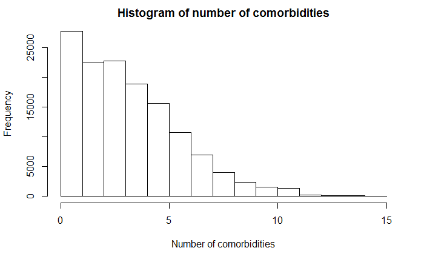

```r
dat2[, race := ifelse(race=="", "U", race)]
antip_names <- colnames(dat2)[grep("antiplatelet", colnames(dat2))]
dat2[, (antip_names) := lapply(.SD, function(x) ifelse(is.na(x), 0, x)), .SDcols = antip_names]
dat2[, ("antiplatelet") := (rowSums(.SD) > 0), .SDcols=antip_names]
dat2[,c("race", "division", "product", "education", "fed_poverty","income_range", "networth_range", "occupation")] <- lapply(dat2[,c("race", "division", "product", "education", "fed_poverty","income_range", "networth_range", "occupation")], as.factor)
# pdf("a1_hist_n_comorbidities.pdf")
hist(dat2$n_comorb, main="Histogram of number of comorbidities",
     xlab="Number of comorbidities")
```

```r
# dev.off()
# scaled age
dat2$age_s <- scale(dat2$age)
# center age by mean
dat2$age_c <- dat2$age - mean(dat2$age)
# combine the smallest education level to the next level
dat2[,education2 := as.factor(ifelse(as.character(education) %in% c("B", "A"), "AB", as.character(education)))]
# use the largest level as the reference level
dat2 <- within(dat2, education <- relevel(education, ref = "C"))
dat2 <- within(dat2, education2 <- relevel(education2, ref = "C"))
dat2 <- within(dat2, race <- relevel(race, ref = "W"))
dat2 <- within(dat2, income_range <- relevel(income_range, ref = "6"))
# combine asian and hispanic for race
dat2[,race2 := as.factor(ifelse(as.character(race) %in% c("H", "A"), "AsianHispanic", as.character(race)))]
# combine regions for division
dat2 <- data.table(dat2 %>%
  mutate(division2 = case_when(
    division %in% c("WEST SOUTH CENTRAL", "WEST NORTH CENTRAL") ~ "WEST CENTRAL",
    division %in% c("EAST SOUTH CENTRAL", "EAST NORTH CENTRAL") ~ "EAST CENTRAL",
    division %in% c("SOUTH ATLANTIC", "MIDDLE ATLANTIC", "NEW ENGLAND") ~ "ATLANTIC_ENGLAND",
    division %in% c("MOUNTAIN", "PACIFIC") ~ "MOUNTAIN_PACIFIC",
    TRUE ~ "UNKNOWN"
  )))
# combine insurace type
dat2[,product2 := as.factor(ifelse(as.character(product) %in% c("EPO", "IND", "PPO"), "EPO_IND_PPO", as.character(product)))]
```

# Compare proportions of LMWH at indexAC versus AC3Mo

```r
dat3 <- melt(dat2, measure.vars = c("index_ac_lmwh", "ac3mo_lmwh"),
             value.name = "LMWH", variable.name = "time")
dat3[, c("clmid", "fill_dt", "category", "brand_name", "gen_name", "copay", "copay_sum", "days_sup", "quantity","strength", "npi", "index_ac_warfarin", "ac3mo_warfarin"):=NULL]
dat4 <- unique(dat3)
dat4[, index_vte_type2 := ifelse(index_vte_type %in% c("IVC", "Portal vein", "Renal vein"), "ivc_rv_rv", index_vte_type)]
sample_id <- sample(unique(dat4$patid),2000, replace = FALSE)
sample_dat <- dat4[dat4$patid %in% sample_id,]
# obtain variable names for index VTE types
# all distinct VTE categories
vte_names0 <- colnames(sample_dat)[grep("VTE_", colnames(sample_dat))]
vte_names1 <- vte_names0[-which(vte_names0 %in% c("VTE_IVC","VTE_Portal.vein", "VTE_Renal.vein"))]
# "VTE_ivc_rv_pv" as the reference level
vte_names_noref <- vte_names1[-which(vte_names1 == "VTE_ivc_rv_pv")]
# example <- sample_dat[sample_dat$patid==factor(sample_dat$patid[1:2]),] %>%  arrange(patid, time)
# kable(example) %>%
  # kable_styling(bootstrap_options = c("striped", "hover"))
```

#### Cell counts of index VTE type by AC

```r
# fit2 <- glmer(LMWH ~ age_c + index_vte_type + (1|patid),data=sample_dat, family = "binomial")
# summary(fit2)

table(dat4$index_vte_type, dat4$LMWH, dat4$time) # notice that ivc, pv, and rv have small counts

table(dat4$index_vte_type2, dat4$LMWH)

# data_index_lmwh <- dat4[time=="index_ac_lmwh", .SD, .SDcols=c(comorb_names, vte_names1, "LMWH")]
# index_lmwh_ct <- aggregate(.~LMWH, data_index_lmwh, sum)
# kable(index_lmwh_ct) %>%
#   kable_styling(bootstrap_options = c("striped", "hover"))

# data_ac3mo_lmwh <- dat4[time=="ac3mo_lmwh", .SD, .SDcols=c(comorb_names, vte_names1, "LMWH")]
# aggregate(.~LMWH, data_ac3mo_lmwh, sum)
# kable(outcome_lmwh_ct) %>%
#   kable_styling(bootstrap_options = c("striped", "hover"))
```

## glmer ————————–

### Model 5 using GLMM

No issue with convergence

```r
# "VTE_ivc_pv_rv" as reference level for index VTE; "comorbidity.Aids.HIV" as reference level for comorbidities
fm5 <- as.formula(paste("LMWH~", paste(c(vte_names_noref, comorb_names[-1]), collapse="+"), "+ age_s + time + race + male + education + (1|patid)")) #income_range + product +

system.time(fit5 <- glmer(fm5, data=sample_dat, family = "binomial", control=glmerControl(optimizer="bobyqa", optCtrl=list(maxfun=1e8))))
summary(fit5)
```

[output not shown]

### Model 6

Does not converge.

```r
# "VTE_ivc_pv_rv" as reference level for index VTE; "comorbidity.Aids.HIV" as reference level for comorbidities
fm6 <- as.formula(paste("LMWH~", paste(c(vte_names_noref, comorb_names[-1]), collapse="+"), "+ age_s + time + race + male + education + income_range + (1|patid)")) # product +

system.time(fit6 <- glmer(fm6, data=sample_dat, family = "binomial", control=glmerControl(optimizer="bobyqa", optCtrl=list(maxfun=1e8))))
summary(fit6)
```

[output not shown]

Model does not converge

```r
fm7 <- as.formula(paste("LMWH~", paste(vte_names_noref, collapse="+"), "+ age_s + n_comorb + time + race2 + male + education2 + vte_history + hospitalized + smoke + division2 + income_range + product2 + (1|patid)"))

system.time(fit7 <- glmer(fm7, data=dat4, family = "binomial", control=glmerControl(optimizer="bobyqa", optCtrl=list(maxfun=1e8))))
summary(fit7)
```

```
user   system  elapsed
```

8917.93 1323.02 12052.05 Warning message: In checkConv(attr(opt, “derivs”), opt$par, ctrl = control$checkConv, : Model failed to converge with max|grad| = 0.00144537 (tol = 0.001, component 1)

Generalized linear mixed model fit by maximum likelihood (Laplace Approximation) [glmerMod] Family: binomial ( logit ) Formula: LMWH ~ VTE_Lower.extremity.DVT + VTE_Other + VTE_Pulmonary.embolism + VTE_Upper.extremity.DVT + age_s + n_comorb + time + race2 + male + education2 + vte_history + hospitalized + smoke + division2 + income_range + product2 + (1 | patid) Data: dat4 Control: glmerControl(optimizer = “bobyqa”, optCtrl = list(maxfun = 1e+08))

```
 AIC      BIC   logLik deviance df.resid
```

18726.9 18992.6 -9331.4 18662.9 29858

Scaled residuals: Min 1Q Median 3Q Max -2.15168 -0.01208 -0.00331 -0.00179 2.50483

Random effects: Groups Name Variance Std.Dev. patid (Intercept) 236.9 15.39 Number of obs: 29890, groups: patid, 14945

Fixed effects: Estimate Std. Error z value Pr(>|z|) (Intercept) -7.85762 0.42069 -18.678 < 2e-16 *VTE_Lower.extremity.DVT -0.32544 0.18190 -1.789 0.0736 . VTE_Other -0.31542 0.21695 -1.454 0.1460 VTE_Pulmonary.embolism -0.03910 0.19489 -0.201 0.8410 VTE_Upper.extremity.DVT -0.04135 0.23495 -0.176 0.8603 age_s -0.35242 0.08649 -4.075 4.61e-05* n_comorb -0.02679 0.03296 -0.813 0.4163 timeac3mo_lmwh -3.31369 0.13237 -25.034 < 2e-16 *** race2B -0.16493 0.31857 -0.518 0.6047 race2U -0.15712 0.44922 -0.350 0.7265 race2W -0.32714 0.26088 -1.254 0.2098 male 0.04100 0.14175 0.289 0.7724 education2AB -0.17739 0.17537 -1.012 0.3118 education2D 0.29349 0.20756 1.414 0.1574 education2U -0.12149 0.60483 -0.201 0.8408 vte_history -0.30135 0.26873 -1.121 0.2621 hospitalizedTRUE 0.30805 0.18020 1.710 0.0874 . smokeTRUE -0.28982 1.40857 -0.206 0.8370 division2EAST CENTRAL -0.20482 0.19493 -1.051 0.2934 division2MOUNTAIN_PACIFIC -0.40714 0.21280 -1.913 0.0557 . division2UNKNOWN -0.29945 1.22417 -0.245 0.8068 division2WEST CENTRAL -0.24492 0.19358 -1.265 0.2058 income_range0 -0.17411 0.27458 -0.634 0.5260 income_range1 -0.29347 0.23760 -1.235 0.2168 income_range2 -0.24305 0.30152 -0.806 0.4202 income_range3 -0.26689 0.30420 -0.877 0.3803 income_range4 0.02785 0.25914 0.107 0.9144 income_range5 -0.16132 0.23810 -0.678 0.4981 product2HMO -0.09311 0.23695 -0.393 0.6944 product2OTH 0.02255 0.24754 0.091 0.9274 product2POS 0.36218 0.21722 1.667 0.0954 . — Signif. codes: 0 ‘**’ 0.001 ’**’ 0.01 ’’ 0.05 ‘.’ 0.1 ‘’ 1

Correlation matrix not shown by default, as p = 31 > 12. Use print(x, correlation=TRUE) or vcov(x) if you need it

convergence code: 0 Model failed to converge with max|grad| = 0.00144537 (tol = 0.001, component 1)

### Model 8:

Run on full data:

```r
fm8 <- as.formula(paste("LMWH~", paste(vte_names_noref, collapse="+"), " + comorb01 + age_s + time + race + male + education2 + income_range + (1|patid)"))

system.time(fit8 <- glmer(fm8, data=dat4, family = "binomial", control=glmerControl(optimizer="bobyqa", optCtrl=list(maxfun=1e8))))
summary(fit8)
```

user system elapsed 1025.97 160.89 1428.84

Generalized linear mixed model fit by maximum likelihood (Laplace Approximation) [glmerMod] Family: binomial ( logit ) Formula: LMWH ~ VTE_Lower.extremity.DVT + VTE_Other + VTE_Pulmonary.embolism + VTE_Upper.extremity.DVT + comorb01 + age_s + time + race + male + education2 + income_range + (1 | patid) Data: dat4 Control: glmerControl(optimizer = “bobyqa”, optCtrl = list(maxfun = 1e+08))

```
 AIC      BIC   logLik deviance df.resid
```

18721.6 18912.6 -9337.8 18675.6 29867

Scaled residuals: Min 1Q Median 3Q Max -2.15842 -0.01221 -0.00317 -0.00182 2.50831

Random effects: Groups Name Variance Std.Dev. patid (Intercept) 239.4 15.47 Number of obs: 29890, groups: patid, 14945

Fixed effects: Estimate Std. Error z value Pr(>|z|) (Intercept) -8.53712 0.35672 -23.932 < 2e-16 *VTE_Lower.extremity.DVT -0.31950 0.18161 -1.759 0.0785 . VTE_Other -0.31014 0.21690 -1.430 0.1528 VTE_Pulmonary.embolism -0.04875 0.19432 -0.251 0.8019 VTE_Upper.extremity.DVT -0.03081 0.23462 -0.131 0.8955 comorb01TRUE 0.23311 0.25467 0.915 0.3600 age_s -0.47121 0.07283 -6.470 9.79e-11* timeac3mo_lmwh -3.32705 0.13274 -25.065 < 2e-16 *** raceA 0.70059 0.49606 1.412 0.1579 raceB 0.17886 0.21691 0.825 0.4096 raceH 0.14591 0.29712 0.491 0.6234 raceU 0.18464 0.38267 0.483 0.6294 male 0.03692 0.14071 0.262 0.7930 education2AB -0.12439 0.17312 -0.718 0.4725 education2D 0.30553 0.20660 1.479 0.1392 education2U -0.16928 0.60275 -0.281 0.7788 income_range0 -0.24273 0.27311 -0.889 0.3741 income_range1 -0.36925 0.23438 -1.575 0.1152 income_range2 -0.31217 0.30029 -1.040 0.2985 income_range3 -0.30832 0.30323 -1.017 0.3093 income_range4 0.00880 0.25812 0.034 0.9728 income_range5 -0.18566 0.23731 -0.782 0.4340 — Signif. codes: 0 ‘**’ 0.001 ’**’ 0.01 ’’ 0.05 ‘.’ 0.1 ‘’ 1

Correlation matrix not shown by default, as p = 22 > 12. Use print(x, correlation=TRUE) or vcov(x) if you need it

```r
# individual predicted probabilities
pred.ind_fit8 <- predict(fit8,type="response")

pdf("a1_predicted_prob_fit8.pdf")
hist(pred.ind_fit8, breaks=40, xlab="Predicted probability",
     main="LMWH ~ VTE_Lower.extremity.DVT + VTE_Other + \n VTE_Pulmonary.embolism + VTE_Upper.extremity.DVT + \n comorb01 + age_s + n_comorb + time + race + \n male + education2 + income_range + (1 | patid)")
while (!is.null(dev.list()))  dev.off()

summary(pred.ind_fit8)
```

```
 Min.   1st Qu.    Median      Mean   3rd Qu.      Max.
```

0.0000014 0.0000069 0.0001138 0.1747420 0.0004659 0.9981103

```r
pars <- getME(fit8,c("theta","fixef"))
fit8.restart <- update(fit8, start=pars)
summary(fit8.restart)
```

### No convergence issue with GLM:

```r
fm.glm <- as.formula(paste("LMWH~", paste(vte_names_noref, collapse="+"), "+ n_comorb + age_s + time + race + male + education + income_range + product"))
glm(fm.glm, data = dat4, family = "binomial")
```

[output not shown]

## GEE ————————————

### Model 7 using GEE

```r
fm7.gee <- as.formula(paste("LMWH~", paste(c(vte_names_noref, comorb_names[-1]), collapse="+"), "+ age_s + time + race + male + education + vte_history + hospitalized + smoke"))

model7.gee <- geeglm(fm7.gee, family = "binomial", id=patid, data = dat4, corstr="exchangeable")
summary(model7.gee)
```

Call: geeglm(formula = fm7, family = “binomial”, data = dat4, id = patid, corstr = “exchangeable”)

Coefficients: Estimate Std.err Wald (Intercept) -1.2787 0.0589 471.75 VTE_Lower.extremity.DVT -0.2210 0.0405 29.72 VTE_Other -0.2158 0.0484 19.89 VTE_Pulmonary.embolism -0.0065 0.0434 0.02 VTE_Upper.extremity.DVT 0.0241 0.0527 0.21 comorbidity.Alcohol.abuse 0.0118 0.1057 0.01 comorbidity.Blood.loss.anemia -0.1753 0.0955 3.37 comorbidity.Cardiac.arrhythmia 0.0187 0.0378 0.24 comorbidity.Cerebrovascular.disease 0.0560 0.0478 1.37 comorbidity.Chronic.pulmonary.disease -0.1151 0.0353 10.63 comorbidity.Congestive.heart.failure -0.1519 0.0514 8.75 comorbidity.Deficiency.anemia -0.1278 0.0478 7.14 comorbidity.Dementia -0.0889 0.1172 0.57 comorbidity.Diabetes.with.chronic.complication -0.1069 0.0728 2.16 comorbidity.Diabetes.without.chronic.complication 0.0391 0.0415 0.89 comorbidity.Drug.abuse 0.0195 0.1058 0.03 comorbidity.Hemiplegia.or.paraplegia 0.3951 0.0885 19.94 comorbidity.Hypertension -0.0637 0.0370 2.97 comorbidity.Mild.liver.disease 0.4936 0.0357 190.82 comorbidity.Moderate.or.severe.liver.disease 0.1632 0.1437 1.29 comorbidity.Myocardial.infarction -0.0238 0.0648 0.14 comorbidity.Obesity -0.2383 0.0462 26.55 comorbidity.Peptic.ulcer.disease 0.3429 0.0818 17.56 comorbidity.Peripheral.vascular.disease -0.1753 0.0477 13.52 comorbidity.Renal.disease -0.1428 0.0488 8.57 comorbidity.Rheumatic.disease -0.0814 0.0733 1.24 comorbidity.Thrombocytopenia 0.2229 0.0491 20.64 comorbidity.Valvular.disease -0.0737 0.0454 2.63 age_s -0.3615 0.0168 463.71 timeac3mo_lmwh -0.4574 0.0314 212.94 raceA 0.4737 0.1095 18.73 raceB 0.1707 0.0486 12.33 raceH 0.1044 0.0683 2.33 raceU 0.1213 0.0845 2.06 male 0.0203 0.0320 0.40 educationA -0.4027 0.2997 1.81 educationB -0.1486 0.0372 16.00 educationD 0.2804 0.0439 40.88 educationU -0.1656 0.1263 1.72 vte_history -0.2804 0.0593 22.34 hospitalizedTRUE 0.2097 0.0405 26.81 smokeTRUE -0.2141 0.3116 0.47 Pr(>|W|)  
(Intercept) < 2e-16 *VTE_Lower.extremity.DVT 5.0e-08* VTE_Other 8.2e-06 VTE_Pulmonary.embolism 0.88109  
VTE_Upper.extremity.DVT 0.64710  
comorbidity.Alcohol.abuse 0.91068  
comorbidity.Blood.loss.anemia 0.06642 .  
comorbidity.Cardiac.arrhythmia 0.62075  
comorbidity.Cerebrovascular.disease 0.24120  
comorbidity.Chronic.pulmonary.disease 0.00112 comorbidity.Congestive.heart.failure 0.00310 **comorbidity.Deficiency.anemia 0.00753** comorbidity.Dementia 0.44856  
comorbidity.Diabetes.with.chronic.complication 0.14185  
comorbidity.Diabetes.without.chronic.complication 0.34529  
comorbidity.Drug.abuse 0.85390  
comorbidity.Hemiplegia.or.paraplegia 8.0e-06 comorbidity.Hypertension 0.08506 .  
comorbidity.Mild.liver.disease < 2e-16 comorbidity.Moderate.or.severe.liver.disease 0.25585  
comorbidity.Myocardial.infarction 0.71309  
comorbidity.Obesity 2.6e-07 **comorbidity.Peptic.ulcer.disease 2.8e-05** *comorbidity.Peripheral.vascular.disease 0.00024* **comorbidity.Renal.disease 0.00341** comorbidity.Rheumatic.disease 0.26627  
comorbidity.Thrombocytopenia 5.5e-06 comorbidity.Valvular.disease 0.10490  
age_s < 2e-16 timeac3mo_lmwh < 2e-16 *raceA 1.5e-05* raceB 0.00045 raceH 0.12668  
raceU 0.15127  
male 0.52621  
educationA 0.17908  
educationB 6.3e-05 educationD 1.6e-10 educationU 0.18960  
vte_history 2.3e-06 hospitalizedTRUE 2.2e-07 *** smokeTRUE 0.49213  
— Signif. codes: 0 ‘**’ 0.001 ’**’ 0.01 ’’ 0.05 ‘.’ 0.1 ‘’ 1

Estimated Scale Parameters: Estimate Std.err (Intercept) 0.989 0.0257

Correlation: Structure = exchangeable Link = identity

Estimated Correlation Parameters: Estimate Std.err alpha 0 0 Number of clusters: 29890 Maximum cluster size: 1

### Model 7.2 using GEE

Individual comorbidities are replaced with the number of comorbidities.

```r
fm7.2.gee <- as.formula(paste("LMWH~", paste(vte_names_noref, collapse="+"), "+ age_s + n_comorb + time + race + male + education + vte_history + hospitalized + smoke + division + income_range + product + antiplatelet"))

model7.2.gee <- geeglm(fm7.2.gee, family = "binomial", id=patid, data = dat4, corstr="exchangeable")
summary(model7.2.gee)
```

Call: geeglm(formula = fm7.2.gee, family = “binomial”, data = dat4, id = patid, corstr = “exchangeable”)

Coefficients: Estimate Std.err Wald Pr(>|W|)  
(Intercept) -0.95397 0.09659 97.54 < 2e-16 *VTE_Lower.extremity.DVT -0.24805 0.04087 36.84 1.3e-09* VTE_Other -0.24591 0.04893 25.26 5.0e-07 VTE_Pulmonary.embolism -0.02315 0.04372 0.28 0.59651  
VTE_Upper.extremity.DVT 0.00182 0.05299 0.00 0.97262  
age_s -0.29234 0.01994 214.96 < 2e-16 n_comorb -0.02178 0.00740 8.66 0.00325 ** timeac3mo_lmwh -0.45770 0.03136 213.00 < 2e-16 *raceA 0.47660 0.11127 18.35 1.8e-05* raceB 0.20456 0.04981 16.86 4.0e-05 *raceH 0.15439 0.06833 5.11 0.02385*  
raceU 0.09305 0.08292 1.26 0.26178  
male 0.03240 0.03168 1.05 0.30654  
educationA -0.32711 0.29923 1.20 0.27432  
educationB -0.11372 0.03936 8.35 0.00386 educationD 0.20325 0.04606 19.47 1.0e-05 educationU -0.03291 0.13285 0.06 0.80436  
vte_history -0.29729 0.05965 24.84 6.2e-07 hospitalizedTRUE 0.22501 0.03999 31.66 1.8e-08 smokeTRUE -0.17264 0.31242 0.31 0.58055  
divisionEAST SOUTH CENTRAL -0.66015 0.09801 45.37 1.6e-11 divisionMIDDLE ATLANTIC 0.47042 0.07085 44.08 3.2e-11 *divisionMOUNTAIN -0.45468 0.06572 47.86 4.6e-12* divisionNEW ENGLAND 0.52102 0.07960 42.85 5.9e-11 divisionPACIFIC -0.05719 0.06600 0.75 0.38620  
divisionSOUTH ATLANTIC -0.09760 0.04945 3.90 0.04840  
divisionUNKNOWN -0.20005 0.26910 0.55 0.45723  
divisionWEST NORTH CENTRAL -0.07628 0.06187 1.52 0.21756  
divisionWEST SOUTH CENTRAL -0.17615 0.05906 8.90 0.00286 income_range0 -0.15213 0.06125 6.17 0.01300 *  
income_range1 -0.23985 0.05347 20.12 7.3e-06 **income_range2 -0.21455 0.06755 10.09 0.00149** income_range3 -0.22358 0.06839 10.69 0.00108 income_range4 0.01355 0.05775 0.06 0.81447  
income_range5 -0.12317 0.05334 5.33 0.02095 *  
productHMO -0.25000 0.07573 10.90 0.00096 productIND -0.21693 0.11750 3.41 0.06486 .  
productOTH -0.15445 0.07893 3.83 0.05039 .  
productPOS 0.15515 0.06688 5.38 0.02035 *  
productPPO -0.27014 0.08878 9.26 0.00235 ** antiplateletTRUE 0.01315 0.07993 0.03 0.86933  
— Signif. codes: 0 ‘**’ 0.001 ’**’ 0.01 ’’ 0.05 ‘.’ 0.1 ‘’ 1

Estimated Scale Parameters: Estimate Std.err (Intercept) 0.993 0.0273

Correlation: Structure = exchangeable Link = identity

Estimated Correlation Parameters: Estimate Std.err alpha 0 0 Number of clusters: 29890 Maximum cluster size: 1

### Model 7.3.gee

Use combined categories.

```r
fm7.3.gee <- as.formula(paste("LMWH~", paste(vte_names_noref, collapse="+"), "+ age_s + n_comorb + time + race2 + male + education2 + vte_history + hospitalized + smoke + division2 + income_range + product2 + antiplatelet"))

model7.3.gee <- geeglm(fm7.3.gee, family=binomial("logit"), id=patid, data = dat4, corstr="exchangeable")
summary(model7.3.gee)
```

Call: geeglm(formula = fm7.3.gee, family = binomial(“logit”), data = dat4, id = patid, corstr = “exchangeable”)

Coefficients: Estimate Std.err Wald Pr(>|W|)  
(Intercept) -0.727891 0.093578 60.50 7.3e-15 *VTE_Lower.extremity.DVT -0.258935 0.040648 40.58 1.9e-10* VTE_Other -0.260389 0.048495 28.83 7.9e-08 VTE_Pulmonary.embolism -0.030555 0.043474 0.49 0.48216  
VTE_Upper.extremity.DVT -0.019576 0.052669 0.14 0.71013  
age_s -0.295340 0.018966 242.49 < 2e-16 n_comorb -0.022926 0.007377 9.66 0.00188 ** timeac3mo_lmwh -0.454093 0.031234 211.37 < 2e-16 race2B -0.133808 0.071300 3.52 0.06056 .  
race2U -0.159638 0.098795 2.61 0.10613  
race2W -0.274799 0.058471 22.09 2.6e-06 male 0.024173 0.031542 0.59 0.44346  
education2AB -0.145150 0.038988 13.86 0.00020 *education2D 0.215687 0.045770 22.21 2.4e-06* education2U -0.069601 0.132741 0.27 0.60005  
vte_history -0.290097 0.059135 24.07 9.3e-07 *hospitalizedTRUE 0.227695 0.039773 32.77 1.0e-08* smokeTRUE -0.251203 0.309335 0.66 0.41675  
division2EAST CENTRAL -0.174648 0.043478 16.14 5.9e-05 *division2MOUNTAIN_PACIFIC -0.343219 0.047490 52.23 4.9e-13* division2UNKNOWN -0.271723 0.269389 1.02 0.31314  
division2WEST CENTRAL -0.196376 0.043492 20.39 6.3e-06 *income_range0 -0.154114 0.060897 6.40 0.01138*  
income_range1 -0.253928 0.053057 22.91 1.7e-06 *income_range2 -0.225795 0.067219 11.28 0.00078* **income_range3 -0.224658 0.067822 10.97 0.00092** income_range4 0.021436 0.057569 0.14 0.70964  
income_range5 -0.125208 0.053076 5.57 0.01832  
product2HMO -0.106878 0.053333 4.02 0.04507 *  
product2OTH 0.013188 0.054925 0.06 0.81024  
product2POS 0.295238 0.049233 35.96 2.0e-09 *** antiplateletTRUE -0.000745 0.079370 0.00 0.99252  
— Signif. codes: 0 ‘**’ 0.001 ’**’ 0.01 ’’ 0.05 ‘.’ 0.1 ‘’ 1

Estimated Scale Parameters: Estimate Std.err (Intercept) 0.992 0.0248

Correlation: Structure = exchangeable Link = identity

Estimated Correlation Parameters: Estimate Std.err alpha 0 0 Number of clusters: 29890 Maximum cluster size: 1

## MCMCglmm —————————

```r
fm7.3.mcmc <- as.formula(paste("LMWH~", paste(vte_names_noref, collapse="+"), "+ age_s + n_comorb + time + race2 + male + education2 + vte_history + hospitalized + smoke + division2 + income_range + product2"))

# prior.12 <-list(R = list(V = diag(1), nu = 0.002), G = list(G1 = list(V = diag(3) * 0.02, nu = 4), G2 = list(V = 1, nu = 0.002)))

dat7.mcmc_nm <- c("patid",vte_names_noref,  "comorb01", "n_comorb","age_s", "time", "race2", "male", "education2", "vte_history", "hospitalized", "smoke", "division2","income_range", "product2", "LMWH")
dat7.mcmc <- na.omit(dat4[,..dat7.mcmc_nm])
dat7.mcmc$education <- factor(dat7.mcmc$education)

system.time(fit7.3.mcmc <- MCMCglmm(fm7.3.mcmc, random=~patid, data=dat7.mcmc, family="categorical", verbose=TRUE, burnin=10000, nitt = 60000, thin = 50))#, singular.ok = TRUE
#singular.ok  logical: if FALSE linear dependencies in the fixed effects are removed. if TRUE they are left in an estimated, although all information comes form the prior

summary(fit7.3.mcmc)
```

Acceptance ratio for liability set 1 = 0.439680

```
                   MCMC iteration = 53000
```

Acceptance ratio for liability set 1 = 0.410104

```
                   MCMC iteration = 54000
```

Acceptance ratio for liability set 1 = 0.405354

```
                   MCMC iteration = 55000
```

Acceptance ratio for liability set 1 = 0.409163

```
                   MCMC iteration = 56000
```

Acceptance ratio for liability set 1 = 0.349179

```
                   MCMC iteration = 57000
```

Acceptance ratio for liability set 1 = 0.313271

```
                   MCMC iteration = 58000
```

Acceptance ratio for liability set 1 = 0.323771

```
                   MCMC iteration = 59000
```

Acceptance ratio for liability set 1 = 0.359087

```
                   MCMC iteration = 60000
```

Acceptance ratio for liability set 1 = 0.328444 user system elapsed 2255.72 514.78 4478.55

Iterations = 10001:59951 Thinning interval = 50 Sample size = 1000

DIC: 18006.95

G-structure: ~patid

```
  post.mean l-95% CI u-95% CI eff.samp
```

patid 7.374 5.359 9.401 1.415

R-structure: ~units

```
  post.mean l-95% CI u-95% CI eff.samp
```

units 0.007391 0.001934 0.01722 5.281

Location effects: LMWH ~ VTE_Lower.extremity.DVT + VTE_Other + VTE_Pulmonary.embolism + VTE_Upper.extremity.DVT + age_s + n_comorb + time + race2 + male + education2 + vte_history + hospitalized + smoke + division2 + income_range + product2

```
                       post.mean   l-95% CI   u-95% CI eff.samp  pMCMC
```

(Intercept) -1.5280626 -1.8645386 -1.1645555 27.019 <0.001 *VTE_Lower.extremity.DVT -0.3825554 -0.5338258 -0.2440470 18.982 <0.001* VTE_Other -0.3395268 -0.5200930 -0.1809920 31.945 <0.001 *VTE_Pulmonary.embolism -0.0275733 -0.2063152 0.1251811 17.285 0.762 VTE_Upper.extremity.DVT -0.0211874 -0.2143854 0.2029877 22.768 0.782 age_s -0.5398630 -0.6408625 -0.4386055 6.483 <0.001* n_comorb -0.0476709 -0.0717331 -0.0225915 76.909 <0.001 *timeac3mo_lmwh -0.8148824 -0.9143202 -0.6750909 3.571 <0.001* race2B -0.2975308 -0.5624199 0.0399526 28.109 0.060 . race2U -0.4049738 -0.7242019 0.0274188 36.496 0.030 *race2W -0.5069491 -0.8233675 -0.2022609 4.807 <0.001* **male 0.0009415 -0.1104842 0.1170362 20.417 0.978 education2AB -0.2693957 -0.4170456 -0.1223277 15.311 <0.001** *education2D 0.4116493 0.2405928 0.5671342 39.157 <0.001* **education2U -0.0634913 -0.5500650 0.4579832 31.184 0.840 vte_history -0.3436429 -0.6460267 0.0086305 1.216 0.054 . hospitalizedTRUE 0.3824243 0.1803095 0.5459227 9.348 <0.001** *smokeTRUE -0.2584298 -1.6892554 0.7968735 6.889 0.758 division2EAST CENTRAL -0.3044702 -0.4625437 -0.1420741 28.343 <0.001* **division2MOUNTAIN_PACIFIC -0.6031960 -0.8038369 -0.4318594 15.337 <0.001** *division2UNKNOWN -0.6371916 -1.5549301 0.2729645 25.635 0.182 division2WEST CENTRAL -0.3572666 -0.5275838 -0.2133891 26.026 <0.001* **income_range0 -0.2722616 -0.5580014 0.0015215 5.343 0.030 *income_range1 -0.3678596 -0.5921705 -0.1452114 11.877 <0.001*** income_range2 -0.3323066 -0.5606086 -0.0761757 30.389 0.006 **income_range3 -0.3456692 -0.5703658 -0.0950944 45.627 0.002** income_range4 0.0621106 -0.1915712 0.2864192 12.638 0.568 income_range5 -0.1697137 -0.3982619 0.0352526 10.307 0.156 product2HMO -0.1537667 -0.3227043 0.0067204 30.620 0.056 . product2OTH 0.1077513 -0.0648934 0.3004683 24.125 0.250 product2POS 0.5274457 0.3563896 0.6802646 55.815 <0.001 *** — Signif. codes: 0 ‘**’ 0.001 ’**’ 0.01 ’’ 0.05 ‘.’ 0.1 ‘’ 1

```r
png("a1_fit7.3.mcmc_trace_density.png", width = 1600, height = 10000)
par(mfrow=c(31,2), mar=c(1.5,1.5,1.5,1.5))
plot(fit7.3.mcmc$Sol, auto.layout=F) #, cex.main=1.25
title("MCMCglmm: LMWH ~ VTE_Lower.extremity.DVT + VTE_Other + \n VTE_Pulmonary.embolism + VTE_Upper.extremity.DVT + age_s + \n n_comorb + time + race2 + male + education2 + vte_history + \n hospitalized + smoke + division2 + income_range + product2",font=40, outer=TRUE)
dev.off()
```

### Model9: add antiplatelet based on model 7.3.mcmc

This same model was run twice and very different answers were yielded.

```r
fm9.mcmc <- as.formula(paste("LMWH~", paste(vte_names_noref, collapse="+"), "+ age_s + n_comorb + time + race2 + male + education2 + vte_history + hospitalized + smoke + division2 + income_range + product2 + antiplatelet"))

# prior.12 <-list(R = list(V = diag(1), nu = 0.002), G = list(G1 = list(V = diag(3) * 0.02, nu = 4), G2 = list(V = 1, nu = 0.002)))

dat9.mcmc_nm <- c("patid",vte_names_noref,  "comorb01", "n_comorb","age_s", "time", "race2", "male", "education2", "vte_history", "hospitalized", "smoke", "division2","income_range", "product2", "antiplatelet", "LMWH")
dat9.mcmc <- na.omit(dat4[,..dat9.mcmc_nm])

system.time(fit9.mcmc <- MCMCglmm(fm9.mcmc, random=~patid, data=dat9.mcmc, family="categorical", verbose=TRUE, burnin=10000, nitt = 60000, thin = 50))#, singular.ok = TRUE
#singular.ok  logical: if FALSE linear dependencies in the fixed effects are removed. if TRUE they are left in an estimated, although all information comes form the prior

summary(fit9.mcmc)
```

*First run:

Acceptance ratio for liability set 1 = 0.412811

```
                   MCMC iteration = 53000
```

Acceptance ratio for liability set 1 = 0.427589

```
                   MCMC iteration = 54000
```

Acceptance ratio for liability set 1 = 0.359889

```
                   MCMC iteration = 55000
```

Acceptance ratio for liability set 1 = 0.347461

```
                   MCMC iteration = 56000
```

Acceptance ratio for liability set 1 = 0.318886

```
                   MCMC iteration = 57000
```

Acceptance ratio for liability set 1 = 0.271246

```
                   MCMC iteration = 58000
```

Acceptance ratio for liability set 1 = 0.252690

```
                   MCMC iteration = 59000
```

Acceptance ratio for liability set 1 = 0.219151

```
                   MCMC iteration = 60000
```

Acceptance ratio for liability set 1 = 0.201220 user system elapsed 2367.60 566.97 3010.14

Iterations = 10001:59951 Thinning interval = 50 Sample size = 1000

DIC: 17332.03

G-structure: ~patid

```
  post.mean l-95% CI u-95% CI eff.samp
```

patid 10.31 6.484 13.95 1.215

R-structure: ~units

```
  post.mean l-95% CI u-95% CI eff.samp
```

units 0.01956 0.003016 0.03672 5.388

Location effects: LMWH ~ VTE_Lower.extremity.DVT + VTE_Other + VTE_Pulmonary.embolism + VTE_Upper.extremity.DVT + age_s + n_comorb + time + race2 + male + education2 + vte_history + hospitalized + smoke + division2 + income_range + product2 + antiplatelet

```
                      post.mean  l-95% CI  u-95% CI eff.samp  pMCMC
```

(Intercept) -1.693033 -2.108257 -1.256714 20.828 <0.001 *VTE_Lower.extremity.DVT -0.533418 -0.757219 -0.336283 14.288 <0.001* VTE_Other -0.509395 -0.790540 -0.290552 8.294 <0.001 *VTE_Pulmonary.embolism -0.085543 -0.258955 0.094183 53.826 0.356 VTE_Upper.extremity.DVT -0.007297 -0.226752 0.231060 27.446 0.968 age_s -0.600997 -0.727246 -0.468625 6.669 <0.001* n_comorb -0.049505 -0.090622 -0.015021 10.413 <0.001 *timeac3mo_lmwh -0.979000 -1.192136 -0.774431 3.155 <0.001* race2B -0.209637 -0.541118 0.084073 22.293 0.200 race2U -0.199972 -0.667311 0.271289 24.266 0.404 race2W -0.470103 -0.788994 -0.130234 4.181 0.008 **male 0.007589 -0.147964 0.151938 23.389 0.882 education2AB -0.291649 -0.573469 -0.066446 4.236 0.006** education2D 0.413208 0.168612 0.625536 38.002 <0.001 *education2U -0.144186 -0.682659 0.457481 31.930 0.622 vte_history -0.502347 -0.783766 -0.233945 22.394 <0.001* hospitalizedTRUE 0.451948 0.265724 0.636473 31.541 <0.001 *smokeTRUE -0.417654 -2.164456 0.898164 12.411 0.632 division2EAST CENTRAL -0.352274 -0.556832 -0.151324 13.096 <0.001* division2MOUNTAIN_PACIFIC -0.588605 -0.814441 -0.379136 23.018 <0.001 *division2UNKNOWN -0.783951 -1.870146 0.290978 21.503 0.188 division2WEST CENTRAL -0.434298 -0.635611 -0.239161 31.483 <0.001* income_range0 -0.391193 -0.669554 -0.103064 23.800 0.006 **income_range1 -0.485817 -0.769600 -0.217174 11.892 <0.001** * income_range2 -0.453391 -0.755309 -0.158175 39.543 0.004 **income_range3 -0.409876 -0.835809 -0.041498 5.684 0.026 *income_range4 0.074236 -0.208086 0.362947 31.161 0.538 income_range5 -0.254488 -0.544214 0.008117 18.910 0.058 . product2HMO -0.185036 -0.416027 0.035455 36.556 0.114 product2OTH 0.041304 -0.206228 0.300631 25.599 0.696 product2POS 0.603173 0.381950 0.810374 28.157 <0.001*** antiplateletTRUE -0.029420 -0.378946 0.304293 36.374 0.850 — Signif. codes: 0 ‘**’ 0.001 ’**’ 0.01 ’’ 0.05 ‘.’ 0.1 ‘’ 1

- Second run: Acceptance ratio for liability set 1 = 0.245853

  ```
                 MCMC iteration = 56000
  ```

Acceptance ratio for liability set 1 = 0.257748

```
                   MCMC iteration = 57000
```

Acceptance ratio for liability set 1 = 0.265468

```
                   MCMC iteration = 58000
```

Acceptance ratio for liability set 1 = 0.289998

```
                   MCMC iteration = 59000
```

Acceptance ratio for liability set 1 = 0.263022

```
                   MCMC iteration = 60000
```

Acceptance ratio for liability set 1 = 0.224934 user system elapsed 2232.19 385.28 2792.97

Iterations = 10001:59951 Thinning interval = 50 Sample size = 1000

DIC: 18085.75

G-structure: ~patid

```
  post.mean l-95% CI u-95% CI eff.samp
```

patid 6.512 5.028 7.557 2.525

R-structure: ~units

```
  post.mean l-95% CI u-95% CI eff.samp
```

units 0.00493 0.002174 0.01156 7.079

Location effects: LMWH ~ VTE_Lower.extremity.DVT + VTE_Other + VTE_Pulmonary.embolism + VTE_Upper.extremity.DVT + age_s + n_comorb + time + race2 + male + education2 + vte_history + hospitalized + smoke + division2 + income_range + product2 + antiplatelet

```
                      post.mean  l-95% CI  u-95% CI eff.samp  pMCMC
```

(Intercept) -1.462096 -1.756647 -1.178204 52.237 <0.001 *VTE_Lower.extremity.DVT -0.340742 -0.501059 -0.168969 4.941 <0.001* VTE_Other -0.409279 -0.581536 -0.196915 7.328 <0.001 *VTE_Pulmonary.embolism 0.050037 -0.092858 0.200106 13.958 0.504 VTE_Upper.extremity.DVT 0.074087 -0.139253 0.316628 4.380 0.594 age_s -0.522083 -0.581200 -0.453055 47.673 <0.001* n_comorb -0.043853 -0.078143 -0.014686 7.673 0.004 **timeac3mo_lmwh -0.780326 -0.865847 -0.692448 3.554 <0.001** *race2B -0.296520 -0.591999 -0.029765 7.798 0.060 . race2U -0.278965 -0.656167 0.053843 24.107 0.108 race2W -0.445308 -0.655164 -0.190153 9.201 <0.001* **male -0.006795 -0.115961 0.095373 11.884 0.928 education2AB -0.266133 -0.385376 -0.150664 93.482 <0.001** *education2D 0.327174 0.132389 0.510003 8.017 <0.001* **education2U -0.097493 -0.649805 0.468670 3.187 0.710 vte_history -0.537578 -0.734501 -0.348668 14.101 <0.001** *hospitalizedTRUE 0.402280 0.270387 0.523788 89.713 <0.001* **smokeTRUE -0.517169 -1.674558 0.374838 25.532 0.312 division2EAST CENTRAL -0.263909 -0.452408 -0.097768 8.523 <0.001** *division2MOUNTAIN_PACIFIC -0.561521 -0.740648 -0.377991 5.485 <0.001* **division2UNKNOWN -0.260904 -0.966242 0.555428 21.352 0.492 division2WEST CENTRAL -0.288431 -0.442233 -0.152357 17.381 <0.001** *income_range0 -0.264044 -0.537470 -0.019277 8.268 0.030* income_range1 -0.409355 -0.578842 -0.231196 21.441 <0.001 **income_range2 -0.303659 -0.502876 -0.103476 55.289 0.002** income_range3 -0.395814 -0.634700 -0.191547 37.632 <0.001 **income_range4 0.019501 -0.168817 0.244878 16.665 0.860 income_range5 -0.142500 -0.344873 0.048894 11.994 0.166 product2HMO -0.222417 -0.381343 -0.048308 17.793 0.004** product2OTH 0.075403 -0.094081 0.267763 8.632 0.472 product2POS 0.392196 0.218156 0.575282 12.370 <0.001 *** antiplateletTRUE -0.002253 -0.229364 0.263670 18.530 0.950 — Signif. codes: 0 ‘**’ 0.001 ’**’ 0.01 ’’ 0.05 ‘.’ 0.1 ‘’ 1

```r
png("a1_fit9.mcmc_trace_density2.png", width = 1800, height = 12000)
par(mfrow=c(32,2), mar=c(1.7,1.7,1.7,1.7))
plot(fit9.mcmc$Sol, auto.layout=F, cex=10, cex.lab=1.5, cex.axis=1.5,) #, cex.main=1.25
title("Second run \n MCMCglmm: LMWH ~ VTE_Lower.extremity.DVT + VTE_Other + \n VTE_Pulmonary.embolism + VTE_Upper.extremity.DVT + age_s + \n n_comorb + time + race2 + male + education2 + vte_history + \n hospitalized + smoke + division2 + income_range + product2 + antiplatelet", outer=TRUE)
dev.off()
```

[output not shown]

Signif. codes: 0 ‘**’ 0.001 ’**’ 0.01 ’’ 0.05 ‘.’ 0.1 ‘’ 1

## Plot predicted probabilities:

```r
# individual coefficients including fixed and random effects
coef.ind.1w <- coef(fit1.w)$patid

# individual predicted probabilities
pred.ind.1w <- predict(fit1.w,type="response")

pdf("a1_predicted_prob_fit1.w.pdf")
hist(pred.ind.1w, breaks = 40, xlab="Predicted probability",
     main="warfarin ~ index_vte_type + comorbidities + n_comorb + time + \n race2 + male + age_s + product2 + income_range + education2 \n + hospitalized + vte_history + smoke + division2 + antiplatelet")
while (!is.null(dev.list()))  dev.off()

summary(pred.ind.1w)
```

Min. 1st Qu. Median Mean 3rd Qu. Max. 0.02964 0.21326 0.68331 0.59483 0.91259 0.98812

### Model 2:

Same covariates as fm7.3.gee

```r
summary(fit2.w.gee)
```

```
Call:
geeglm(formula = fm2.w.gee, family = binomial("logit"), data = dat5,
    id = patid, corstr = "exchangeable")

 Coefficients:
                          Estimate  Std.err   Wald Pr(>|W|)
(Intercept)               -0.06279  0.07386   0.72  0.39528
VTE_Lower.extremity.DVT    0.15401  0.03118  24.40  7.8e-07 ***
VTE_Other                  0.27557  0.03694  55.66  8.6e-14 ***
VTE_Pulmonary.embolism     0.02185  0.03309   0.44  0.50891
VTE_Upper.extremity.DVT    0.04769  0.04214   1.28  0.25769
age_s                      0.15859  0.01559 103.45  < 2e-16 ***
n_comorb                   0.02297  0.00565  16.55  4.7e-05 ***
timeac3mo_warfarin        -0.39390  0.02409 267.40  < 2e-16 ***
race2B                     0.08323  0.05663   2.16  0.14162
race2U                    -0.09637  0.07965   1.46  0.22631
race2W                     0.16548  0.04691  12.44  0.00042 ***
male                       0.02527  0.02457   1.06  0.30382
education2AB               0.12462  0.02963  17.69  2.6e-05 ***
education2D               -0.14224  0.03814  13.91  0.00019 ***
education2U                0.12285  0.10180   1.46  0.22752
vte_history                0.03692  0.04404   0.70  0.40186
hospitalizedTRUE           0.00741  0.03223   0.05  0.81807
smokeTRUE                 -0.09353  0.22747   0.17  0.68093
division2EAST CENTRAL      0.18441  0.03387  29.64  5.2e-08 ***
division2MOUNTAIN_PACIFIC  0.27257  0.03626  56.50  5.6e-14 ***
division2UNKNOWN           0.62981  0.20822   9.15  0.00249 **
division2WEST CENTRAL      0.17272  0.03424  25.44  4.6e-07 ***
income_range0              0.29831  0.04871  37.51  9.1e-10 ***
income_range1              0.35436  0.04103  74.59  < 2e-16 ***
income_range2              0.24253  0.05129  22.36  2.3e-06 ***
income_range3              0.31212  0.05235  35.55  2.5e-09 ***
income_range4              0.10268  0.04721   4.73  0.02962 *
income_range5              0.16054  0.04303  13.92  0.00019 ***
product2HMO                0.19858  0.03934  25.48  4.5e-07 ***
product2OTH               -0.28838  0.04040  50.96  9.4e-13 ***
product2POS               -0.25273  0.03899  42.02  9.1e-11 ***
antiplateletTRUE          -0.03293  0.05798   0.32  0.57008
---
Signif. codes:  0 *** 0.001 ** 0.01 * 0.05 . 0.1   1

Estimated Scale Parameters:
            Estimate Std.err
(Intercept)    0.999 0.00409

Correlation: Structure = exchangeable  Link = identity

Estimated Correlation Parameters:
      Estimate Std.err
alpha        0       0
Number of clusters:   29890   Maximum cluster size: 1
```

### Model 3

```r
# dat3.w.mcmc_nm <- c("patid",vte_names_noref,  "comorb01", "n_comorb","age_s", "time", "race2", "male", "education2", "vte_history", "hospitalized", "smoke", "division2","income_range", "product2", "LMWH")
# dat7.mcmc <- na.omit(dat4[,..dat7.mcmc_nm])

fm2.w.mcmc <- as.formula(paste("warfarin~", paste(vte_names_noref, collapse="+"), "+ age_s + n_comorb + time + race2 + male + education2 + vte_history + hospitalized + smoke + division2 + income_range + product2"))

system.time(fit3.w.mcmc <- MCMCglmm(fm2.w.mcmc, random=~patid, data=dat5, family="categorical", verbose=TRUE, burnin=10000, nitt = 60000, thin = 50))#, singular.ok = TRUE
#singular.ok  logical: if FALSE linear dependencies in the fixed effects are removed. if TRUE they are left in an estimated, although all information comes form the prior

summary(fit3.w.mcmc)
```

Acceptance ratio for liability set 1 = 0.661895

```
                   MCMC iteration = 56000
```

Acceptance ratio for liability set 1 = 0.717415

```
                   MCMC iteration = 57000
```

Acceptance ratio for liability set 1 = 0.738912

```
                   MCMC iteration = 58000
```

Acceptance ratio for liability set 1 = 0.757214

```
                   MCMC iteration = 59000
```

Acceptance ratio for liability set 1 = 0.779827

```
                   MCMC iteration = 60000
```

Acceptance ratio for liability set 1 = 0.787201 user system elapsed 2290.11 487.43 2875.46

Iterations = 10001:59951 Thinning interval = 50 Sample size = 1000

DIC: 27337.86

G-structure: ~patid

```
  post.mean l-95% CI u-95% CI eff.samp
```

patid 10.58 8.713 11.78 2.77

R-structure: ~units

```
  post.mean l-95% CI u-95% CI eff.samp
```

units 0.03725 0.00848 0.1076 4.496

Location effects: warfarin ~ VTE_Lower.extremity.DVT + VTE_Other + VTE_Pulmonary.embolism + VTE_Upper.extremity.DVT + age_s + n_comorb + time + race2 + male + education2 + vte_history + hospitalized + smoke + division2 + income_range + product2

```
                      post.mean l-95% CI u-95% CI eff.samp  pMCMC
```

(Intercept) -0.25635 -0.65015 0.22547 36.47 0.268 VTE_Lower.extremity.DVT 0.34994 0.16883 0.52018 40.99 <0.001 *VTE_Other 0.64960 0.43254 0.82501 82.69 <0.001* VTE_Pulmonary.embolism 0.06972 -0.11478 0.23042 63.86 0.458 VTE_Upper.extremity.DVT 0.14292 -0.08041 0.36868 78.33 0.206 age_s 0.35452 0.26740 0.44431 40.62 <0.001 *n_comorb 0.05524 0.02316 0.08463 51.59 <0.001* timeac3mo_warfarin -0.89589 -0.99403 -0.80982 13.16 <0.001 **race2B 0.22745 -0.10745 0.52590 44.58 0.146 race2U -0.19423 -0.56760 0.24524 93.59 0.350 race2W 0.40296 0.13223 0.68701 53.98 0.004** male 0.06327 -0.06054 0.19160 101.66 0.342 education2AB 0.28562 0.12597 0.43699 39.19 <0.001 **education2D -0.29165 -0.50950 -0.07649 49.54 0.002** education2U 0.37075 -0.17193 0.99890 56.78 0.198 vte_history 0.08505 -0.14835 0.33641 65.69 0.514 hospitalizedTRUE 0.02103 -0.18801 0.18455 63.57 0.776 smokeTRUE -0.29898 -1.50480 0.84703 64.75 0.612 division2EAST CENTRAL 0.43328 0.23707 0.60206 32.14 <0.001 *division2MOUNTAIN_PACIFIC 0.64027 0.46599 0.84919 53.93 <0.001* division2UNKNOWN 1.46944 0.45313 2.39074 69.54 <0.001 *division2WEST CENTRAL 0.42099 0.24340 0.61315 47.58 <0.001* income_range0 0.69700 0.43546 0.97934 48.29 <0.001 *income_range1 0.83630 0.61048 1.08925 49.83 <0.001* income_range2 0.54678 0.27067 0.79262 45.74 <0.001 *income_range3 0.71345 0.39969 1.01723 32.24 <0.001* income_range4 0.25646 0.02174 0.54230 57.62 0.058 . income_range5 0.39623 0.15264 0.63063 45.54 <0.001 *product2HMO 0.43918 0.22806 0.65238 42.94 <0.001* product2OTH -0.62450 -0.83198 -0.38152 74.88 <0.001 *product2POS -0.56001 -0.79416 -0.36693 53.29 <0.001* — Signif. codes: 0 ‘**’ 0.001 ’**’ 0.01 ’’ 0.05 ‘.’ 0.1 ‘’ 1

Use glmer: Running in Rstudio results in error:

```r
fm3.w <- as.formula(paste("warfarin~", paste(c(vte_names_noref), collapse="+"), "+ n_comorb + time + race + male+ age_s + product + income_range + (1 |patid)"))  # + networth_range  + comorb01 + education +
system.time(fit3.w <- glmer(fm3.w, data=dat5, family = "binomial", control=glmerControl(optimizer="bobyqa", optCtrl=list(maxfun=1e8))))
summary(fit3.w)
```

Error in qr.default(X, tol = tol, LAPACK = FALSE) : NA/NaN/Inf in foreign function call (arg 1) Timing stopped at: 0.03 0.02 0.05

But no convergence issue in command line. (???)

user system elapsed 143.78 3.53 156.79

```
 AIC      BIC   logLik deviance df.resid
```

4638.2 4820.0 -2290.1 4580.2 3869

Scaled residuals: Min 1Q Median 3Q Max -1.7616 -0.4103 0.2199 0.3538 1.4337

Random effects: Groups Name Variance Std.Dev. patid (Intercept) 7.5 2.739 Number of obs: 3898, groups: patid, 1949

Fixed effects: Estimate Std. Error z value Pr(>|z|) (Intercept) 0.79579 0.60371 1.318 0.187449 VTE_Lower.extremity.DVT 0.21047 0.21266 0.990 0.322325 VTE_Other 0.38524 0.24810 1.553 0.120488 VTE_Pulmonary.embolism 0.05843 0.22541 0.259 0.795456 VTE_Upper.extremity.DVT 0.07442 0.29225 0.255 0.799007 n_comorb 0.09627 0.03867 2.490 0.012789 *timeac3mo_warfarin -0.71968 0.09874 -7.289 3.12e-13* **raceA -1.05560 0.56866 -1.856 0.063414 . raceB -0.03939 0.25547 -0.154 0.877471 raceH 0.55765 0.38733 1.440 0.149948 raceU -1.08210 0.47410 -2.282 0.022465 *male -0.16695 0.17290 -0.966 0.334264 age_s 0.30072 0.11737 2.562 0.010401* productHMO 0.40726 0.40567 1.004 0.315421 productIND -1.03105 0.56872 -1.813 0.069842 . productOTH -1.09651 0.42704 -2.568 0.010238 *productPOS -0.96338 0.38028 -2.533 0.011299* productPPO -0.21255 0.48220 -0.441 0.659356 income_range0 1.33328 0.34717 3.840 0.000123** *income_range1 0.95790 0.26932 3.557 0.000376* ** income_range2 0.83052 0.34539 2.405 0.016191 * income_range3 1.15312 0.36129 3.192 0.001414 ** income_range4 0.79731 0.31767 2.510 0.012078 *income_range5 0.57898 0.29289 1.977 0.048066* occupation2 -0.33282 0.54205 -0.614 0.539217 occupation3 -0.82382 0.60535 -1.361 0.173545 occupation4 -0.23474 0.48145 -0.488 0.625865 occupationU -0.13419 0.40325 -0.333 0.739303 — Signif. codes: 0 ‘**’ 0.001 ’**’ 0.01 ’’ 0.05 ‘.’ 0.1 ‘’ 1

Correlation matrix not shown by default, as p = 28 > 12. Use print(x, correlation=TRUE) or vcov(x) if you need it

```r
png("a1_fit3.w.mcmc_trace_density.png", width = 1600, height = 10000)
par(mfrow=c(31,2), mar=c(1.5,1.5,1.5,1.5))
plot(fit3.w.mcmc$Sol, auto.layout=F) #, cex.main=1.25
title("MCMCglmm: LMWH ~ VTE_Lower.extremity.DVT + VTE_Other + \n VTE_Pulmonary.embolism + VTE_Upper.extremity.DVT + \n n_comorb + time + race + male + age_s + product + \n income_range + occupation",font=40, outer=TRUE)
dev.off()
```

### Model 4:

```r
fm4.w <- as.formula(paste("warfarin~", paste(c(vte_names_noref.w), collapse="+"), "+ n_comorb + time + race + male+ age_s + product + income_range + networth_range  + (1 |patid)"))  #   + comorb01 + education +
system.time(fit4.w <- glmer(fm4.w, data=test_sample_warfarin, family = "binomial", control=glmerControl(optimizer="bobyqa", optCtrl=list(maxfun=1e8))))
summary(fit4.w)
```

Command line output:

user system elapsed 708.25 12.18 752.38

```
 AIC      BIC   logLik deviance df.resid
```

4643.4 4862.8 -2286.7 4573.4 3863

Scaled residuals: Min 1Q Median 3Q Max -1.7220 -0.4111 0.2166 0.3547 1.4532

Random effects: Groups Name Variance Std.Dev. patid (Intercept) 7.5 2.739 Number of obs: 3898, groups: patid, 1949

Fixed effects: Estimate Std. Error z value Pr(>|z|) (Intercept) 1.26883 1.08605 1.168 0.24268 VTE_Lower.extremity.DVT 0.19185 0.21344 0.899 0.36874 VTE_Other 0.37550 0.24829 1.512 0.13044 VTE_Pulmonary.embolism 0.04790 0.22569 0.212 0.83192 VTE_Upper.extremity.DVT 0.05739 0.29281 0.196 0.84463 n_comorb 0.09808 0.03886 2.524 0.01161 *timeac3mo_warfarin -0.72081 0.09883 -7.294 3.02e-13* ** raceA -1.00666 0.56898 -1.769 0.07686 . raceB -0.01015 0.25966 -0.039 0.96880 raceH 0.57698 0.38900 1.483 0.13801 raceU -1.04156 0.47442 -2.195 0.02813 * male -0.16500 0.17308 -0.953 0.34044 age_s 0.31882 0.12274 2.597 0.00939 ** productHMO 0.45794 0.40667 1.126 0.26014 productIND -0.97815 0.56944 -1.718 0.08584 . productOTH -1.04386 0.42790 -2.440 0.01471 *productPOS -0.91839 0.38069 -2.412 0.01585* productPPO -0.17513 0.48353 -0.362 0.71721 income_range0 0.90221 0.85125 1.060 0.28921 income_range1 0.79617 0.31811 2.503 0.01232 * income_range2 0.69495 0.36849 1.886 0.05931 . income_range3 1.01295 0.37930 2.671 0.00757 ** income_range4 0.67325 0.33025 2.039 0.04149 * income_range5 0.51485 0.29829 1.726 0.08435 . home_ownership -0.43882 0.31909 -1.375 0.16906 networth_range1 -0.24912 0.93926 -0.265 0.79084 networth_range2 -0.14944 0.91361 -0.164 0.87007 networth_range3 0.35165 0.93028 0.378 0.70543 networth_range4 0.13528 0.92951 0.146 0.88428 networth_range5 -0.20019 0.93594 -0.214 0.83063 occupation2 -0.36683 0.54326 -0.675 0.49953 occupation3 -0.86738 0.60735 -1.428 0.15325 occupation4 -0.27631 0.48315 -0.572 0.56740 occupationU -0.17564 0.40466 -0.434 0.66427 — Signif. codes: 0 ‘**’ 0.001 ’**’ 0.01 ’’ 0.05 ‘.’ 0.1 ‘’ 1

Correlation matrix not shown by default, as p = 34 > 12. Use print(x, correlation=TRUE) or vcov(x) if you need it

## Plot predicted probabilities:

```r
# individual coefficients including fixed and random effects
coef.ind.4w <- coef(fit4.w)$patid

# individual predicted probabilities
pred.ind.4w <- predict(fit4.w,type="response")

pdf("a1_predicted_prob_fit4.w.pdf")
hist(pred.ind.4w, breaks = 40, xlab="Predicted probability",
     main="warfarin ~ index_vte_type + comorbidities + time + \n race + male + age_s + income_range + education")
while (!is.null(dev.list()))  dev.off()

summary(pred.ind)
```

```r
fm4.w <- as.formula(paste("warfarin~", paste(c(vte_names_noref.w), collapse="+"), "+ n_comorb + time + race + male+ age_s + product + income_range + networth_range  + (1 |patid)"))  #   + comorb01 + education +
system.time(fit4.w <- glmer(fm4.w, data=test_sample_warfarin, family = "binomial", control=glmerControl(optimizer="bobyqa", optCtrl=list(maxfun=1e8))))
summary(fit4.w)
```